# S1: Derivation of infinite population approximation

Bob Week https://bobweek.github.io (University of Idaho)https://ibest.uidaho.edu , Scott Nuismer https://leeef.org  
2019-03-26

### Derivation of base model

To eliminate confusion, we provide a full derivation of our model. This derivation is closely related to the one Kimura employed for their continuum of alleles model(Kimura 1965; B&uuml;rger 2000) (especially see section 1.2 of (Crow and Kimura 1970)), but is sufficiently different that we provide our own treatment here.

We begin with an axiom of biological populations. If each individual produces $\mathscr W$ offspring, then, given $N$ parents, we have $\mathscr WN$ offspring. For non-overlapping generations, this results in the dynamical equation $N_{t+1}=\mathscr WN_t$. For continuously reproducing populations, suppose $N_{t+h}={\mathscr W}^hN_t, \ h\in[0,1]$. Then

$$\begin{equation}
\frac{d}{dt}N_t\equiv\lim_{h\rightarrow 0}\frac{N_{t+h}-N_t}{h}=(\ln \mathscr W)N_t.
\end{equation}$$

Now suppose that $\mathscr W(z)$ is a function of some phenotypic parameter $z\in\mathbb{R}$ and $n_t(z)$ denotes the abundance density of this value in the population. Restating the above equation

$$\frac{d}{dt}n_t(z)=\ln \mathscr W(z)n_t(z).$$

The total abundance of the population is $N_t=\int_\mathbb{R}n_t(z)dz$ and hence (applying the dominated convergence theorem)

$$\frac{d}{dt}N_t=\int_\mathbb{R}\ln \mathscr W(z)n_t(z)dz$$

$$=\left(\int_\mathbb{R}\ln \mathscr W(z)\phi_t(z)dz\right)N_t=\overline{\ln \mathscr W}N_t.$$

Here $\phi_t(z)=n_t(z)/N_t$ denotes the relative density of trait value $z$ in the population. Using a similar trick one can calculate the continuous time response to selection as

$$\frac{\partial\phi_t}{\partial t}=(\ln \mathscr W-\overline{\ln \mathscr W})\phi_t.$$

In evolutionary game theory this is often referred to as the replicator equation(Page and Nowak 2002). If the population is finite then $\phi_t(z)$ cannot be a true probability density function, but rather a probability mass function. To circumvent this we assume the population size is infinite such that every phenotypic value is expressed by an infinite number of individuals and therefore corresponds to a density. Since the replicator equation is independent of population size it holds in the limit $N_t\rightarrow\infty$. Under this assumption, the response of the mean phenotype $\bar z_t$ to selection is (again applying the dominated convergence theorem whose mention we suppress for the remainder of this derivation)

$$\frac{d\bar z_t}{dt}=\frac{d}{dt}\int_\mathbb{R}z\phi_t(z)dz=\int_\mathbb{R}z\frac{d}{dt}\phi_t(z)dz$$

$$=\int_\mathbb{R}z(\ln\mathscr W(z)-\overline{\ln\mathscr W})\phi_t(z)dz=\mathrm{Cov}(z,\ln \mathscr W).$$

When $\phi_t$ is Gaussian with variance ${\sigma_t}^2$, a direct calculation (similar to that used by (Lande 1976)) then shows

$$\frac{d\bar z_t}{dt}={\sigma_t}^2\left(\frac{\partial\overline{\ln \mathscr W}}{\partial\bar z_t}-\frac{\overline{\partial\ln \mathscr W}}{\partial\bar z_t}\right).$$

However, if $\mathscr W$ is not Gaussian, the replicator equation demonstrates that $\phi_t$ immediately diverges from being strictly Gaussian. Previous theory argues that random mating and Gaussian mutational effects retain at least approximate normality of $\phi_t$(Slatkin 1987). However, so far our derivation has not considered the effects of reproduction and imperfect heritability. To account for these processes we start by assuming each individual carries a genotypic value $x$ related to $z$ by $z\sim\mathscr{N}(x,\nu^2)$ where the variance $\nu^2$ represents developmental noise. Offspring inherit the genotypic value stochastically so that if a parent has genotypic value $x$, its offspring will have genotypic value $x'\sim\mathscr{N}(x,\eta^2)$ where the variance $\eta^2$ represents the effects of mutation. Note this also assumes asexual selection, which we keep for now as a simplifying assumption.

Since we are assuming infinite populations the abundance of these populations no longer concern us. Hence, we consider the Malthusian fitness of a genetic value $x$, (ie, $\ln\mathscr W(x)$), instead of the expected reproductive output of an individual with genetic value $x$, (ie, $\mathscr{W}(x)$). Taking into account the fact that selection acts on the expressed phenotype, this Malthusian parameter becomes

$$(\ln\mathscr W)^*(x)=\int_\mathbb{R}\ln\mathscr W(z)\psi(x-z)dz$$

where

$$\psi(x)=\frac{1}{\sqrt{2\pi\nu^2}}\exp\left(-\frac{x^2}{2\nu^2}\right)$$

captures developmental noise (compare to eqn 9 of (Kimura and Crow 1978)). These assumptions imply the mutational extension of the replicator equation

$$\frac{\partial\gamma_t}{\partial t}=\left((\ln\mathscr W)^*-\overline{(\ln\mathscr W)^*}\right)\gamma_t+\frac{\eta^2}{2}\frac{\partial^2\gamma_t}{\partial x^2}$$

where

$$\overline{(\ln\mathscr W)^*}=\int_\mathbb{R}(\ln\mathscr W)^*(x)\gamma_t(x)dx=\int_\mathbb{R}\int_\mathbb{R}\ln\mathscr W(z)\psi(z-x)\gamma_t(x)dzdx.$$

The distribution of expressed phenotypes $\phi_t$ can then be written as

$$\phi_t(z)=\int_\mathbb{R}\gamma_t(x)\psi(z-x)dx.$$

The evolution of the mean genetic value $\bar x_t$ is derived via

$$\frac{d\bar x_t}{d t}=\int_\mathbb{R}x\frac{\partial}{\partial t}\gamma_t(x)dx$$

$$=\int_\mathbb{R}x\left(\left((\ln\mathscr W)^*-\overline{(\ln\mathscr W)^*}\right)\gamma_t(x)+\frac{\eta^2}{2}\frac{\partial^2}{\partial x^2}\gamma_t(x)\right)dx$$

$$=\mathrm{Cov}_\gamma(x,(\ln\mathscr W)^*)+\frac{\eta^2}{2}\int_\mathbb{R}x\frac{\partial ^2}{\partial x^2}\gamma_t(x)dx.$$

When $\gamma_t(x)$ is Gaussian s.t.

$$\gamma_t(x)=\frac{1}{\sqrt{2\pi G_t}}\exp\left(-\frac{(x-\bar x_t)^2}{2G_t}\right)$$

we have $\sigma_t^2=G_t+\nu^2$, but more importantly

$$\frac{\partial^2\gamma_t}{\partial x^2}=\frac{(x-\bar x_t)^2-G_t}{{G_t}^2}\gamma_t$$

and hence

$$\int_\mathbb{R}x\frac{\partial ^2\gamma_t}{\partial x^2}dx=\frac{1}{{G_t}^2}\left(\bar x_t^3-G_t\bar x_t+\int_\mathbb{R}(x^3-2x^2\bar x_t)\gamma_tdx\right)$$

$$=\frac{1}{{G_t}^2}\left(\bar x_t^3-G_t\bar x_t+\bar x_t^3+3\bar x_tG_t-2\bar x_t(\bar x_t^2+G_t)\right)=0.$$

When $\gamma_t$ is Gaussian a direct calculation then shows

$$\frac{d\bar x_t}{dt}=G_t\left(\frac{\partial\overline{(\ln \mathscr W)^*}}{\partial\bar x_t}-\frac{\overline{\partial(\ln \mathscr W)^*}}{\partial\bar x_t}\right)$$

which is the formal continuous time analog of the well known breeders equation introduced by Lande(Lande 1976). Since we assume mutation and developmental noise are unbiased and population size is infinite, the mean genotypic value $\bar x_t$ is equal to the mean expressed phenotype $\bar z_t$ whenever $\gamma_0$ is symmetric around its mean. If we also have a Gaussian $\mathscr{W}(z)$ so that

$$\ln\mathscr W(z)=J-\frac{S}{2}(\theta-z)^2$$

then

$$\overline{(\ln\mathscr W)^*}=J-\frac{S}{2}\left((\theta-\bar x)^2+G_t+\nu^2\right)$$

$$=J-\frac{S}{2}\left((\theta-\bar z)^2+{\sigma_t}^2\right)=\overline{\ln\mathscr W}.$$

For now assume both $G_t=G$ and ${\sigma_t}^2=\sigma^2$ are constant with respect to time and ignore the rigorous mathematical implications of these constraints. Under the offset matching model, the Malthusian fitness of trait value $z_i$ in species $i$ interacting with species $j$ is(Week and Nuismer 2019)

$$\ln\mathscr W_i(z_i)=\int_\mathbb{R}K_i-\frac{B_i}{2}(z_i- \zeta-\delta)^2\phi_j(\zeta)d\zeta$$

$$=K_i-\frac{B_i}{2}\left((z_i-\bar z_j-\delta)^2+\sigma_j^2\right)$$

for some value $K_i\in\mathbb{R}$. Hence

$$\overline{\ln \mathscr W_i}=\ln K_i-\frac{B_i}{2}\left((\bar z_i-\bar z_j-\delta)^2+\sigma_i^2+\sigma_j^2\right)$$

and

$$\frac{d\bar z_i}{dt}=G_iB_i(\delta+\bar z_j-\bar z_i).$$

### Extension to evolving $G$

Here we provide some justification for assuming $G_t=G$ and ${\sigma_t}^2=\sigma^2$ are constant across time. Referring back to the mutational replicator equation, we derive the evolution of $G_t$ by

$$\frac{d G_t}{dt}=\frac{d}{dt}\int_\mathbb{R}(x-\bar x_t)^2\gamma_tdx$$

$$=\int_\mathbb{R}2(x-\bar x_t)\gamma_t(x)\frac{d\bar x_t}{dt}+(x-\bar x_t)^2\frac{d\gamma_t}{dt}dx$$

$$=\mathrm{Cov}\left\{(x-\bar x_t)^2,(\ln \mathscr W)^*\right\}+\frac{\eta^2}{2}\int_\mathbb{R}(x-\bar x_t)^2\frac{\partial^2\gamma_t}{\partial x^2}dx.$$

When $\gamma_t$ is Gaussian we have

$$\int_\mathbb{R}(x-\bar x_t)^2\frac{\partial^2\gamma_t}{\partial x^2}dx=\int_\mathbb{R}(x-\bar x_t)^2\frac{(x-\bar x_t)^2-G_t}{{G_t}^2}\gamma_tdx=2$$

and

$$\frac{\partial\overline{(\ln\mathscr W)^*}}{\partial G_t}
=\int_\mathbb{R}(\ln\mathscr W)^*\frac{\partial\gamma_t}{\partial G_t}+\frac{\partial\overline{(\ln\mathscr W)^*}}{\partial G_t}\gamma_tdx$$

$$=\int_\mathbb{R}(\ln\mathscr W)^*\frac{(x-\bar x_t)^2-G_t}{2{G_t}^2}\gamma_tdx
+\overline{\frac{\partial (\ln\mathscr W)^*}{\partial G_t}}$$

$$=\frac{\mathrm{Cov}\left\{(x-\bar x_t)^2,(\ln\mathscr W)^*\right\}}{2{G_t}^2}+\overline{\frac{\partial(\ln\mathscr W)^*}{\partial G_t}}$$

$$=\frac{1}{2{G_t}^2}\left(\frac{dG_t}{dt}-\eta^2\right)+\overline{\frac{\partial(\ln\mathscr W)^*}{\partial G_t}}.$$

Thus

$$\frac{d G_t}{d t}=\eta^2+2{G_t}^2\left(\frac{\partial\overline{(\ln \mathscr W)^*}}{\partial G_t}-\frac{\overline{\partial(\ln \mathscr W)^*}}{\partial G_t}\right).$$

The offset matching model can then be extended to include the additional equations

$$\frac{d G_i}{d t}=\eta_i^2-B_i{G_i}^2.$$

Under the assumption of infinite populations, the variance of genetic values evolves independently of the value of the mean. Furthermore, this variance evolves directly to the mutation-selection equilibrium $\eta_i/\sqrt B_i$ when $B_i>0$. Assuming the $G_i$ have reached their equilibrium, we arrive back at the simple model derived above. Again, all of these results are exact for infinite population sizes and interactions mediated by exactly one trait. However, in reality interactions are likely mediated by syndromes of traits. Then to capture the full range of dynamics the offset-matching model is capable of, we must generalize our treatment to the case when $\bar z_1,\bar z_2\in\mathbb{R}^d$.

### Extension to multivariate traits

To show that the offset-matching model captures the full range of coevolutionary dynamics discussed in the literature, we generalize the above formulation to $d$-dimensional traits. In this generalization we observe an additional behaviour; cycles. Since the formal derivation is analogous to the above treatment (using multivariate Gaussians instead of univariate ones), we suppress these details here and focus on the resulting model. We find

$$\frac{d\bar z_i}{dt}=G_iB_i(\delta+\bar z_j-\bar z_i)$$

$$\frac{d G_i}{d t}=\eta_i^2-B_i{G_i}^2$$

where these equations are now interpreted as matrix equations. In particular, we have

$$\bar z_i=\left(\begin{matrix}\bar z_i^{(1)}\\\vdots\\\bar z_i^{(d)}\end{matrix}\right), \ \ \delta=\left(\begin{matrix}\delta^{(1)}\\\vdots\\\delta^{(d)}\end{matrix}\right)\in\mathbb{R}^d$$

$$B_i=\left(\begin{matrix}B_i^{(1,1)} & \cdots & B_i^{(1,d)}\\\vdots & \ddots & \vdots \\ B_i^{(d,1)} & \cdots & B_i^{(d,d)}\end{matrix}\right), \ \ G_i=\left(\begin{matrix}G_i^{(1,1)} & \cdots & G_i^{(1,d)}\\\vdots & \ddots & \vdots \\ G_i^{(d,1)} & \cdots & G_i^{(d,d)}\end{matrix}\right),$$

$$\eta_i=\left(\begin{matrix}\eta_i^{(1,1)} & \cdots & \eta_i^{(1,d)}\\\vdots & \ddots & \vdots \\ \eta_i^{(d,1)} & \cdots & \eta_i^{(d,d)}\end{matrix}\right)\in\mathbb{R}^{d\times d}.$$

To find cycles, we only need $d=2$. For simplicity, we assume the $G_i$ are at equilibrium and adopt the notation $\mathscr{B}_i=G_iB_i$. Rewriting the resulting system in matrix notation

$$\frac{d}{dt}\left(\begin{matrix}\bar z_1^{(1)}\\\bar z_1^{(2)}\\\bar z_2^{(1)}\\\bar z_2^{(2)}\end{matrix}\right)
=\left(\begin{matrix}-\mathscr{B}_1^{(1,1)} & -\mathscr{B}_1^{(1,2)} & \mathscr{B}_1^{(1,1)} & \mathscr{B}_1^{(1,2)} \\-\mathscr{B}_1^{(2,1)}&-\mathscr{B}_1^{(2,2)}&\mathscr{B}_1^{(2,1)}&\mathscr{B}_1^{(2,2)}\\\mathscr{B}_2^{(1,1)}&\mathscr{B}_2^{(1,2)}&-\mathscr{B}_2^{(1,1)}&-\mathscr{B}_2^{(1,2)}\\\mathscr{B}_2^{(2,1)}&\mathscr{B}_2^{(2,2)}&-\mathscr{B}_2^{(2,1)}&-\mathscr{B}_2^{(2,2)}\end{matrix}\right)
\left(\begin{matrix}\bar z_1^{(1)}\\\bar z_1^{(2)}\\\bar z_2^{(1)}\\\bar z_2^{(2)}\end{matrix}\right)+
\left(\begin{matrix}
\mathscr{B}_1^{(1,1)}\delta^{(1)}+\mathscr{B}_1^{(1,2)}\delta^{(2)}\\
\mathscr{B}_1^{(2,1)}\delta^{(1)}+\mathscr{B}_1^{(2,2)}\delta^{(2)}\\
\mathscr{B}_2^{(1,1)}\delta^{(1)}+\mathscr{B}_2^{(1,2)}\delta^{(2)}\\
\mathscr{B}_2^{(2,1)}\delta^{(1)}+\mathscr{B}_2^{(2,2)}\delta^{(2)}
\end{matrix}\right)$$

we can directly observe the Jacobian of the system and calculate the eigenvalues $0$ and

$$\scriptsize{\frac{1}{2}\left\{-\left(\mathscr{B}_1^{(1,1)}+\mathscr{B}_1^{(2,2)}+\mathscr{B}_2^{(1,1)}+\mathscr{B}_2^{(2,2)}\right)\pm\sqrt{\left(\mathscr{B}_1^{(1,1)}-\mathscr{B}_1^{(2,2)}+\mathscr{B}_2^{(1,1)}-\mathscr{B}_2^{(2,2)}\right)^2+4\left(\mathscr{B}_1^{(1,2)}+\mathscr{B}_2^{(1,2)}\right)\left(\mathscr{B}_1^{(2,1)}+\mathscr{B}_2^{(2,1)}\right)}\right\}}.$$

This model can therefore explain cycles when the underlying traits are multivariate and the co-selection strengths are not symmetric. As a numerical example suppose we only measure traits $\bar z_1^{(1)}$ and $\bar z_2^{(1)}$ and that the above conditions are satisfied with parameter values listed in Table 1. Then our model suggests the limit cycle observed in Figure 1. For reproducibility we repeat the *R* code used to generate Figure 1 at the end of this document.

Table 1: Parameters for numerical example.

| parameter | value |
| --- | --- |
| δ⁽¹⁾ | 0.0 |
| δ⁽²⁾ | 0.0 |
| ℬ₁⁽¹¹⁾ | 0.0 |
| ℬ₁⁽²²⁾ | 0.0 |
| ℬ₂⁽¹¹⁾ | 0.0 |
| ℬ₂⁽²²⁾ | 0.0 |
| ℬ₁⁽²¹⁾ | -0.6 |
| ℬ₁⁽¹²⁾ | 0.1 |
| ℬ₂⁽²¹⁾ | 0.4 |
| ℬ₂⁽¹²⁾ | 0.5 |

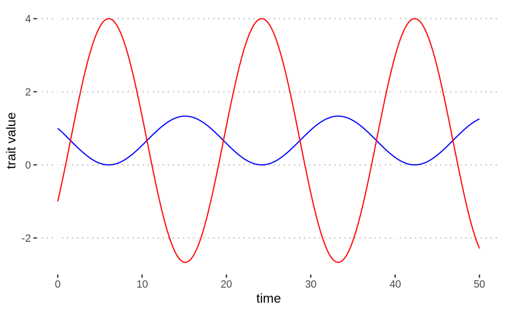

Figure 1: A limit cycle produced by the multivariate offset-matching model.

```r
require(deSolve)
require(ggplot2)
require(ggpubr)
twoDtrait <- function(t, state, parameters) {
  with(as.list(c(state, parameters)), {
    dz11 <-  B111*(z21-z11)+B112*(z22-z12)
    dz12 <-  B121*(z21-z11)+B122*(z22-z12)
    dz21 <-  B211*(z11-z21)+B212*(z12-z22)
    dz22 <-  B221*(z11-z21)+B222*(z12-z22)
    list(c(dz11, dz12, dz21, dz22))
  })
}

parameters <- c(B111 = 0.0, B112 = 0.1, B121 = -0.6, B122 = 0.0,
                B211 = 0.0, B212 = 0.5, B221 =  0.4, B222 = 0.0)
state      <- c(z11=1, z12=1, z21=-1, z22=-1)
times      <- seq(0, 50, by = 0.01)

cycles <- ode(y = state, times = times, func = twoDtrait, parms = parameters)
cycles <- data.frame(cycles)

ggplot(cycles,aes(x=time,y=z11))+geom_line(colour="blue")+
  geom_line(aes(y=z21),colour="red")+theme_pubclean()+
  ylab("trait value")+xlab("time")
```

B&uuml;rger, Reinhard. 2000. *The Mathematical Theory of Selection, Recombination, and Mutation*. Vol. 228. Wiley Chichester.

Crow, James F, and Motoo Kimura. 1970. “An Introduction to Population Genetics Theory.” *An Introduction to Population Genetics Theory.* New York, Evanston; London: Harper & Row, Publishers.

Kimura, M. 1965. “A Stochastic Model Concerning the Maintenance of Genetic Variability in Quantitative Characters.” *Proceedings of the National Academy of Sciences* 54 (3). Proceedings of the National Academy of Sciences: 731–36. https://doi.org/10.1073/pnas.54.3.731.

Kimura, Motoo, and James F Crow. 1978. “Effect of Overall Phenotypic Selection on Genetic Change at Individual Loci.” *Proceedings of the National Academy of Sciences* 75 (12). National Acad Sciences: 6168–71.

Lande, Russell. 1976. “Natural Selection and Random Genetic Drift in Phenotypic Evolution.” *Evolution* 30 (2). Wiley: 314–34. https://doi.org/10.1111/j.1558-5646.1976.tb00911.x.

Page, Karen M., and Martin A. Nowak. 2002. “Unifying Evolutionary Dynamics.” *Journal of Theoretical Biology* 219 (1). Elsevier BV: 93–98. https://doi.org/10.1006/jtbi.2002.3112.

Slatkin, Montgomery. 1987. “Quantitative Genetics of Heterochrony.” *Evolution* 41 (4). Wiley: 799–811. https://doi.org/10.1111/j.1558-5646.1987.tb05854.x.

Week, Bob, and Scott L. Nuismer. 2019. “The Measurement of Coevolution in the Wild.” Edited by Frederick Adler. *Ecology Letters*, February. Wiley. https://doi.org/10.1111/ele.13231.